# Solution Section 3: Data vizualisation

Maximilian H.K. Hesselbarth

2022-06-30 / 2022-07-01

# Load libraries

For this exercise, we are going to use the already cleaned data set from the *palmerpenguins* package again. Thus, load all packages you need first.

```r
library(palmerpenguins)
library(dplyr)
```

# Scatter plot

Create a scatter plot using the two numerical variables you picked in the last exercise to fit a linear regression model. Plot the data (for all species) using point colors that refer to the island the data was collected. Use a solid triangle as point shape.

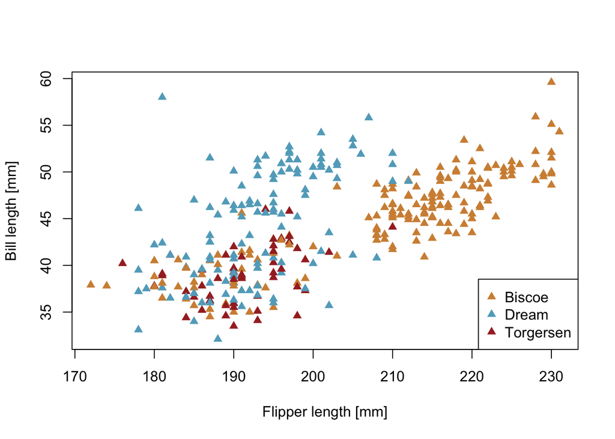

```r
color_palette <- c(Biscoe = "#d28f40", Dream = "#61aac5", Torgersen = "#a62b29")

penguins$island <- factor(penguins$island, levels = c("Biscoe", "Dream", "Torgersen"))

plot(penguins$flipper_length_mm, penguins$bill_length_mm, col = color_palette[penguins$island], pch = 17,
xlab = "Flipper length [mm]", ylab = "Bill length [mm]")

legend("bottomright", legend = c("Biscoe", "Dream", "Torgersen"),
       col = color_palette, pch = 17)
```

Now fit the linear regression model again and add the regression line to the figure. Add a line for the whole data set, but also for all islands individually.

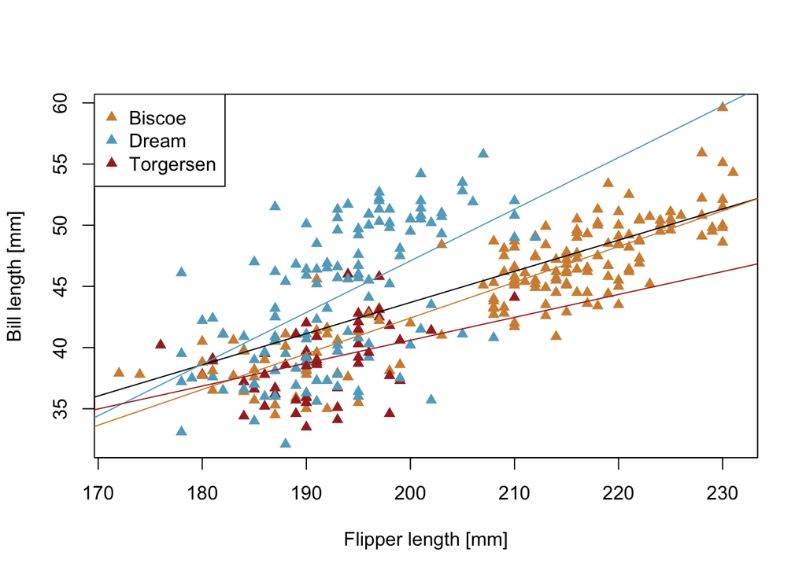

```r
plot(penguins$flipper_length_mm, penguins$bill_length_mm, col = color_palette[penguins$island], pch = 17,
xlab = "Flipper length [mm]", ylab = "Bill length [mm]")

lm_model <- lm(bill_length_mm ~ flipper_length_mm, data = penguins)
abline(lm_model)

lm_island <- dplyr::group_by(penguins, island) %>%
  dplyr::group_split() %>%
  purrr::map(lm, formula = bill_length_mm ~ flipper_length_mm) %>%
  purrr::set_names(c("Biscoe", "Dream", "Torgersen"))

purrr::walk2(lm_island, names(lm_island), function(x,y) abline(x, col = color_palette[y]))

legend("topleft", legend = names(color_palette), col = color_palette,
       pch = 17)
```

# Box plot and Histogram

Create a boxplot for the difference between islands of the body size. Try to also add the raw data points to the boxplot.

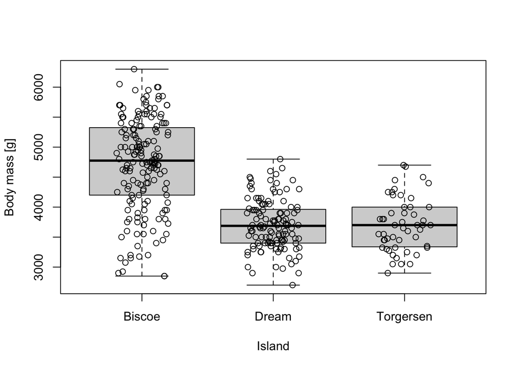

```r
boxplot(body_mass_g ~ island, data = penguins, xlab = "Island", ylab = "Body mass [g]")
points(x = jitter(as.numeric(penguins$island)), y = penguins$body_mass_g)
```

Compare the boxplot visualization to a histogram. Which one do you like more to show differences between the islands? What affect do different `breaks` have on the figure?

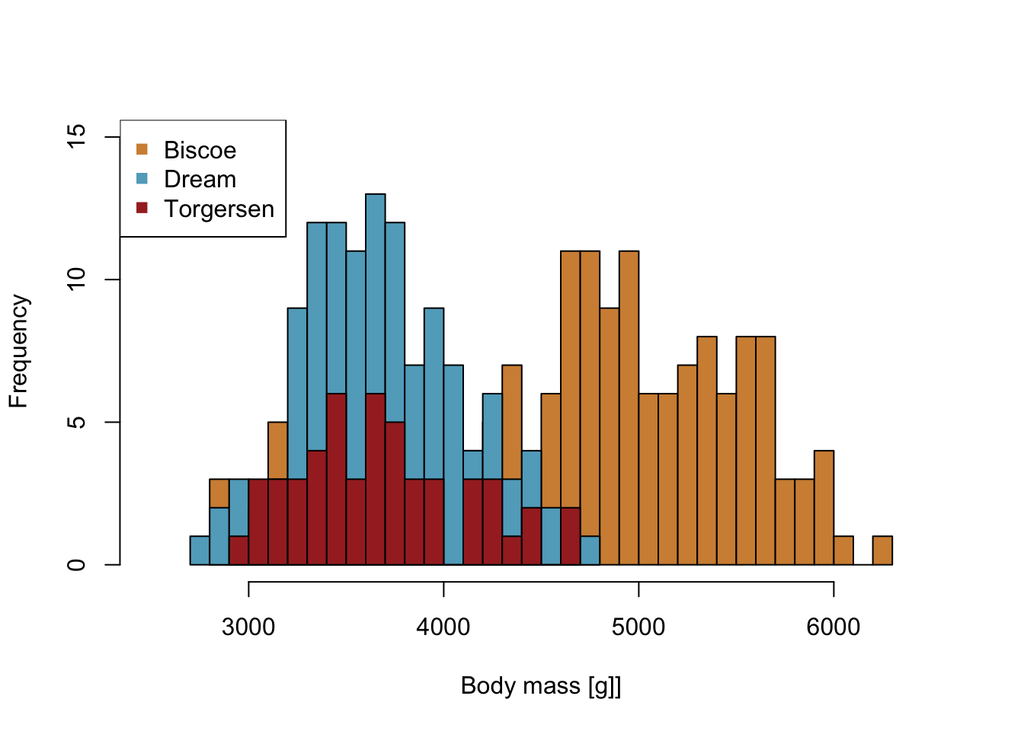

```r
biscoe <- penguins$body_mass_g[penguins$island == "Biscoe"]
dream <- penguins$body_mass_g[penguins$island == "Dream"]
torgersen <- penguins$body_mass_g[penguins$island == "Torgersen"]

hist(biscoe, breaks = 25, col = color_palette[[1]], xlim = c(2500, 6500), ylim = c(0, 15),
     xlab = "Body mass [g]]", main = "")

hist(dream, breaks = 25, col = color_palette[[2]], add = TRUE)

hist(torgersen, breaks = 25, col = color_palette[[3]], add = TRUE)

legend("topleft", legend = names(color_palette), col = color_palette,
       pch = 15)
```

# Exporting

Try to find out how to export the at least one figure as a PDF file.

```r
pdf(file = here::here("Fig-1.pdf"), width = 6, height = 4) # The height of the plot in inches

boxplot(body_mass_g ~ island, data = penguins, xlab = "Island", ylab = "Body mass [g]")
points(x = jitter(as.numeric(penguins$island)), y = penguins$body_mass_g)

dev.off()
```